# Laboratory 5

Simulation, examples and exercises

Spring 2020

# Generalized Linear Models

Many times, linearity between a dependent variable and a set of predictors is not a suited assumption. Normal linear models rely on a *normality assumption*, and this may be a limitation when the nature of the dependent variable is discrete and its range spans from 0 to $+\infty$. In normal linear models, the main assumption is:

$$E[y_i]=\beta_0+\sum_{j=1}^{p}\beta_jx_{ij}.$$

Extending the linear framework allows for the following transformation involving a twice differentiable **link function** g such that:

$$g(E[y_i])=\beta_0+\sum_{j=1}^{p}\beta_jx_{ij}.$$

## Logistic regression

The following example is in the book: *Data analysis using regression and multilevel/ hierarchical models*, Gelman, A., & Hill, J. (2007), Cambridge University Press.

It is known that water in some wells in Bangladesh and other South Asian countries might be contaminated with natural arsenic. The effect of the arsenic ingestion on health is a cumulative poisoning, and the risk of cancer and other diseases is estimated to be proportional to the dose intake.

A research team from the United States and Bangladesh examined the water of several wells in Araihazar district of Bangladeshin and they measured the arsenic level classified the wells as *safe* if the arseic level was below the 0.5 in units of hundreds of micrograms per liter, or *unsafe* if it was above 0.5. All the people using unsafe wells have been encouraged to switch to a nearby well. Indeed the contamination does not depend on the proximity and close wells can have very different levels of arsenic.

The dataset in the file contains information on on whether or not 3020 households in Bangladesh changed the wells that they were using after few years from the arsenic investigation.

- **switch:** whether or not the household switched to another well from an unsafe well: no (0) or yes (1);
- **arsenic:** the level of arsenic contamination in the household’s original well, in hundreds of micrograms per liter; all are above 0.5, which was the level identified as “safe”;
- **distance:** in meters to the closest known safe well;
- **education:** in years of the head of the household;
- **association:** whether or not any members of the household participated in any community organizations: no (0) or yes (1).

```r
data <- read.csv2("Wells.csv", header=TRUE)
str(data)
```

```
## 'data.frame':    3020 obs. of  5 variables:
##  $ switch : int  1 1 0 1 1 1 1 1 1 1 ...
##  $ arsenic: num  2.36 0.71 2.07 1.15 1.1 3.9 2.97 3.24 3.28 2.52 ...
##  $ dist   : num  16.8 47.3 21 21.5 40.9 ...
##  $ assoc  : int  0 0 0 0 1 1 1 0 1 1 ...
##  $ educ   : int  0 0 10 12 14 9 4 10 0 0 ...
```

```r
summary(data)
```

```
##      switch          arsenic           dist             assoc             educ
##  Min.   :0.0000   Min.   :0.510   Min.   :  0.387   Min.   :0.0000   Min.   : 0.000
##  1st Qu.:0.0000   1st Qu.:0.820   1st Qu.: 21.117   1st Qu.:0.0000   1st Qu.: 0.000
##  Median :1.0000   Median :1.300   Median : 36.761   Median :0.0000   Median : 5.000
##  Mean   :0.5752   Mean   :1.657   Mean   : 48.332   Mean   :0.4228   Mean   : 4.828
##  3rd Qu.:1.0000   3rd Qu.:2.200   3rd Qu.: 64.041   3rd Qu.:1.0000   3rd Qu.: 8.000
##  Max.   :1.0000   Max.   :9.650   Max.   :339.531   Max.   :1.0000   Max.   :17.000
```

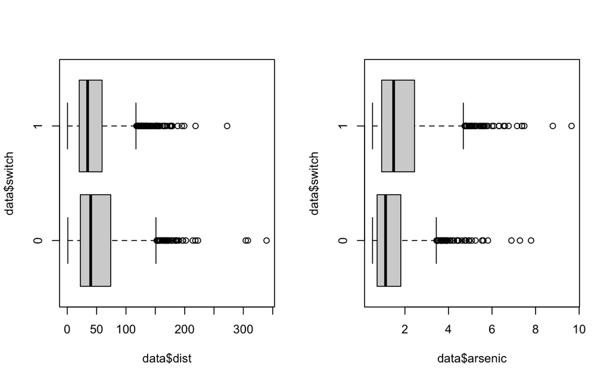

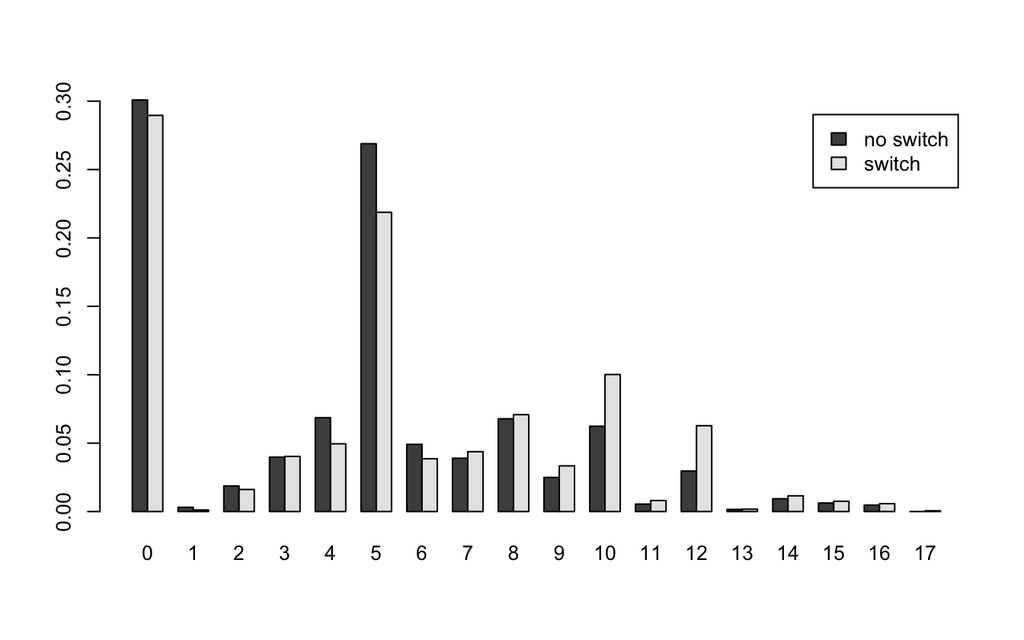

### One predictor

In R:

```r
## Logistic regression with one predictor

fit.1 <- glm(switch ~ dist, family=binomial(link="logit"), data=data)
summary(fit.1)
```

```
##
## Call:
## glm(formula = switch ~ dist, family = binomial(link = "logit"),
##     data = data)
##
## Deviance Residuals:
##     Min       1Q   Median       3Q      Max
## -1.4406  -1.3058   0.9669   1.0308   1.6603
##
## Coefficients:
##               Estimate Std. Error z value Pr(>|z|)
## (Intercept)  0.6059594  0.0603102  10.047  < 2e-16 ***
## dist        -0.0062188  0.0009743  -6.383 1.74e-10 ***
## ---
## Signif. codes:  0 '***' 0.001 '**' 0.01 '*' 0.05 '.' 0.1 ' ' 1
##
## (Dispersion parameter for binomial family taken to be 1)
##
##     Null deviance: 4118.1  on 3019  degrees of freedom
## Residual deviance: 4076.2  on 3018  degrees of freedom
## AIC: 4080.2
##
## Number of Fisher Scoring iterations: 4
```

```r
invlogit <- function (x) {1/(1+exp(-x))}
invlogit(fit.1$coefficients%*%c(1,0))
```

```
##           [,1]
## [1,] 0.6470185
```

Thus the probability of switching well for a family who lives close to a safe well is about $65\%$.

There are two ways of interpreting the coefficients for the predictor $\texttt{dist}$:

- the coefficient for $\texttt{dist}$ can be interpreted as a negative difference of $−0.0062$ in the logit probability of switching well when the distance is increased by one;

Or we can evaluate the difference of the logistic regression function to adding 1 to the predictor $\texttt{dist}$. This difference corresponds to a difference on the probability scale but requires the choice of two specific values of the predictor. The mean of the predictor is a good starting point since it corresponds to the steepest point of the inverse logit function.

Thus, - adding 1 to $\texttt{dist}$ —that is, adding 1 meters to the distance to the nearest safe well— corresponds to a negative difference in the probability of switching of about $0.15\%$ on average.

```r
# difference on the probability to switch well due to an increase of one unit on the predictor from the mean
invlogit(fit.1$coefficients%*%c(1,mean(data$dist)+1))-
  invlogit(fit.1$coefficients%*%c(1,mean(data$dist)))
```

```
##              [,1]
## [1,] -0.001519722
```

Notice that coefficients here does not have a linear effect on the probability that the outcome is 1 because of the nonlinearity of the model. The curve of the logistic function requires us to choose where to evaluate changes, if we want to interpret on the probability scale.

```r
# difference on the probability to switch well due to an increase of one unit on the predictor from the 99 percentile
invlogit(fit.1$coefficients%*%c(1,quantile(data$dist,.99)+1))-
  invlogit(fit.1$coefficients%*%c(1,quantile(data$dist,.99)))
```

```
##              [,1]
## [1,] -0.001465513
```

The effect of one unit increase of the variable $\texttt{dist}$ on the inverse logit seems low, but this is misleading since distance is measured in meters, so this coefficient corresponds to the difference between, say, a house that is 90 meters away from the nearest safe well and a house that is 91 meters away. In order to improve interpretability of the results we rescale distance in 100-meter units.

```r
## Repeat the regression above with distance in 100-meter units
data$dist100 <- data$dist/100
fit.2 <- glm (switch ~ dist100, family=binomial(link="logit"), data=data)
summary(fit.2)
```

```
##
## Call:
## glm(formula = switch ~ dist100, family = binomial(link = "logit"),
##     data = data)
##
## Deviance Residuals:
##     Min       1Q   Median       3Q      Max
## -1.4406  -1.3058   0.9669   1.0308   1.6603
##
## Coefficients:
##             Estimate Std. Error z value Pr(>|z|)
## (Intercept)  0.60596    0.06031  10.047  < 2e-16 ***
## dist100     -0.62188    0.09743  -6.383 1.74e-10 ***
## ---
## Signif. codes:  0 '***' 0.001 '**' 0.01 '*' 0.05 '.' 0.1 ' ' 1
##
## (Dispersion parameter for binomial family taken to be 1)
##
##     Null deviance: 4118.1  on 3019  degrees of freedom
## Residual deviance: 4076.2  on 3018  degrees of freedom
## AIC: 4080.2
##
## Number of Fisher Scoring iterations: 4
```

```r
# difference on the probability scale due to an increase of 1 unit on the predictor (dist100) from the mean
invlogit(fit.2$coefficients%*%c(1,mean(data$dist100)+1))-
  invlogit(fit.2$coefficients%*%c(1,mean(data$dist100)))
```

```
##            [,1]
## [1,] -0.1542287
```

```r
#notice that
# difference on the probability scale due to an increase of 100 unit on the predictor from the mean (fit.1)
invlogit(fit.1$coefficients%*%c(1,mean(data$dist)+100))-
  invlogit(fit.1$coefficients%*%c(1,mean(data$dist)))
```

```
##            [,1]
## [1,] -0.1542287
```

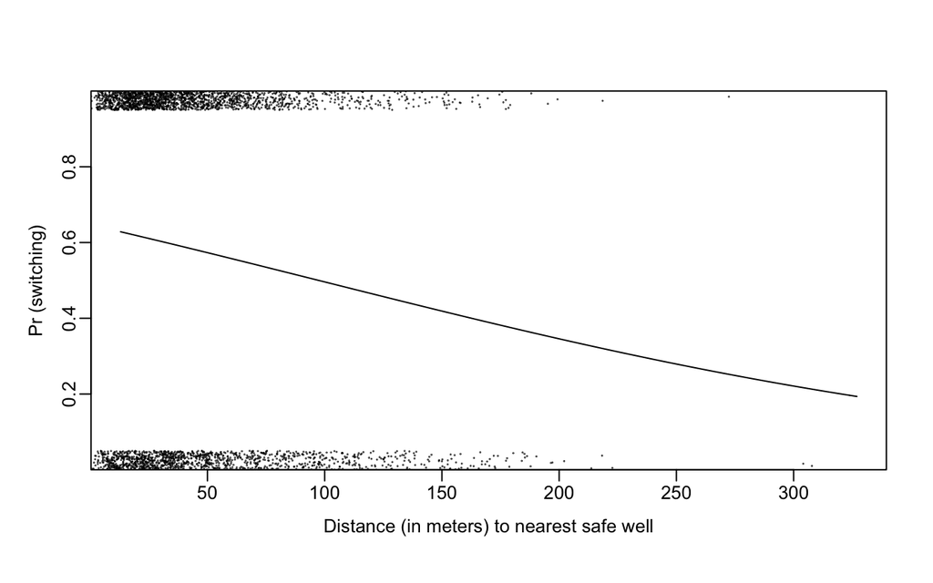

The probability of switching well is about $60\%$ for those who live close to a safe well, declining to about $20\%$ when the distance from a safe well increases up to $300$ meters from their home. This seems reasonable: the probability of switching is higher for people who live closer to a safe well (Gelman-Hill, 2007).

### Adding predictors

We start adding the arsenic level. We expect that the higher the arsenic concentration the higher the probability of switching well, that is, traslated in model terms, a positive sign for the arsenic coefficient.

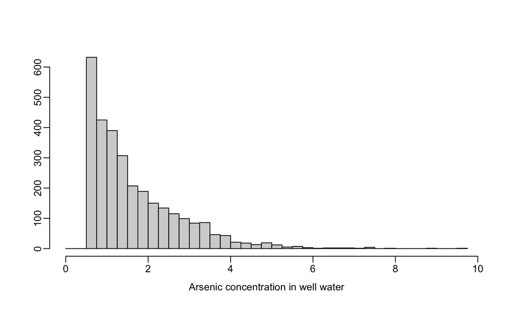

```
##
## Call:
## glm(formula = switch ~ dist100 + arsenic, family = binomial(link = "logit"),
##     data = data)
##
## Deviance Residuals:
##     Min       1Q   Median       3Q      Max
## -2.6351  -1.2139   0.7786   1.0702   1.7085
##
## Coefficients:
##              Estimate Std. Error z value Pr(>|z|)
## (Intercept)  0.002749   0.079448   0.035    0.972
## dist100     -0.896644   0.104347  -8.593   <2e-16 ***
## arsenic      0.460775   0.041385  11.134   <2e-16 ***
## ---
## Signif. codes:  0 '***' 0.001 '**' 0.01 '*' 0.05 '.' 0.1 ' ' 1
##
## (Dispersion parameter for binomial family taken to be 1)
##
##     Null deviance: 4118.1  on 3019  degrees of freedom
## Residual deviance: 3930.7  on 3017  degrees of freedom
## AIC: 3936.7
##
## Number of Fisher Scoring iterations: 4
```

Numerical interpretation of one predictor effect here needs to be done chosing a value for the other predictor. As an example: given two wells with the same arsenic level (notice that it cannot be 0!), the logit probability of switching decreases of $-.90$ every 100 meters in distance to the nearest safe well. Equivalently: for two equally distant nearest safe wells, a difference of 1 in arsenic concentration corresponds to a 0.46 positive difference in the logit probability of switching.

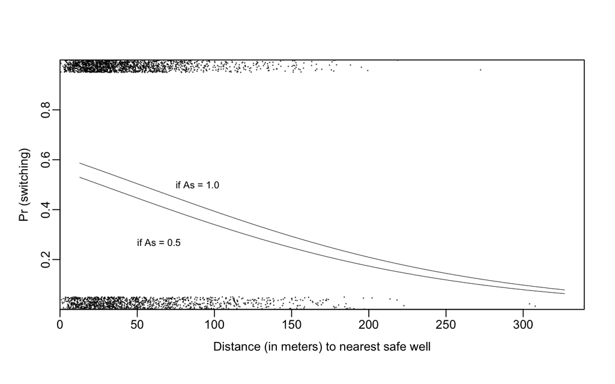

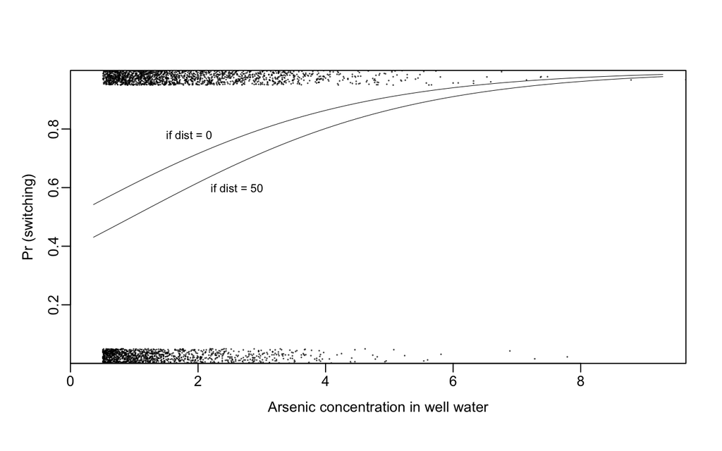

In general terms, the fitted model can be summarized as: switching is easier if there is a nearby safe well, and if a household’s existing well has a high arsenic level, there should be more motivation to switch.

We now want to verify if there is a statistically significant effect of the interaction between the distance and the arsenic concentration on the probability of switching well.

```r
# Logistic regression with interactions

fit.4 <- glm (switch ~ dist100 + arsenic + dist100:arsenic, #switch ~ dist100*arsenic equivalently
  family=binomial(link="logit"), data=data)
summary(fit.4)
```

```
##
## Call:
## glm(formula = switch ~ dist100 + arsenic + dist100:arsenic, family = binomial(link = "logit"),
##     data = data)
##
## Deviance Residuals:
##     Min       1Q   Median       3Q      Max
## -2.7823  -1.2004   0.7696   1.0816   1.8476
##
## Coefficients:
##                 Estimate Std. Error z value Pr(>|z|)
## (Intercept)     -0.14787    0.11754  -1.258  0.20838
## dist100         -0.57722    0.20918  -2.759  0.00579 **
## arsenic          0.55598    0.06932   8.021 1.05e-15 ***
## dist100:arsenic -0.17891    0.10233  -1.748  0.08040 .
## ---
## Signif. codes:  0 '***' 0.001 '**' 0.01 '*' 0.05 '.' 0.1 ' ' 1
##
## (Dispersion parameter for binomial family taken to be 1)
##
##     Null deviance: 4118.1  on 3019  degrees of freedom
## Residual deviance: 3927.6  on 3016  degrees of freedom
## AIC: 3935.6
##
## Number of Fisher Scoring iterations: 4
```

As said before, the interpretation of the coefficients when arsenic is equal to 0 does not make sense, since the minimum level reached is 0.5. We fix the predictors to their mean and so - the probability of switching well for an average distance and for an average arsenic concentration is about $0.59$.

```r
# constant term
invlogit(c(1,mean(data$dist100),mean(data$arsenic),
           mean(data$dist100)*mean(data$arsenic))%*%coefficients(fit.4))
```

```
##           [,1]
## [1,] 0.5868829
```

```r
# an increse of 100 meters in the distance, helding arsenic at its mean
invlogit(c(1,mean(data$dist100)+1,mean(data$arsenic),
           (mean(data$dist100)+1)*mean(data$arsenic))%*%coefficients(fit.4))-
invlogit(c(1,mean(data$dist100),mean(data$arsenic),
           mean(data$dist100)*mean(data$arsenic))%*%coefficients(fit.4))
```

```
##            [,1]
## [1,] -0.2146287
```

```r
# an increse of 1 in the arsenic, helding distance at its mean
invlogit(c(1,mean(data$dist100),mean(data$arsenic)+1,
           (mean(data$dist100))*(mean(data$arsenic)+1))%*%coefficients(fit.4))-
invlogit(c(1,mean(data$dist100),mean(data$arsenic),
           mean(data$dist100)*mean(data$arsenic))%*%coefficients(fit.4))
```

```
##           [,1]
## [1,] 0.1074813
```

- the interaction term can be seen as the effect added to the coefficient for distance for each additional unit of arsenic: at the average level of arsenic, the coefficient for distance is −0.88. Viceversa, at the average level of distance, the coefficient for arsenic is 0.47. So the importance of distance as a predictor increases for households with higher existing arsenic levels and the importance of arsenic decreases for households that are farther from existing safe wells.

```r
coef(fit.4)[2]+coef(fit.4)[4]*mean(data$arsenic)
```

```
##    dist100
## -0.8736527
```

```r
coef(fit.4)[3]+coef(fit.4)[4]*mean(data$dist100)
```

```
##   arsenic
## 0.4695081
```

Interpreting the coefficients is easier when variables are standardized. Coefficients of predictors are now interpretable as the effect of the predictor on the logit probability when the others are at their mean.

```r
## Centering the input variables

data$c.dist100 <- scale(data$dist100, scale = FALSE)
data$c.arsenic <- scale(data$arsenic, scale = FALSE)

## Refitting the model with centered inputs

fit.5 <- glm (switch ~ c.dist100 + c.arsenic + c.dist100:c.arsenic,
  family=binomial(link="logit"), data=data)
summary(fit.5)
```

```
##
## Call:
## glm(formula = switch ~ c.dist100 + c.arsenic + c.dist100:c.arsenic,
##     family = binomial(link = "logit"), data = data)
##
## Deviance Residuals:
##     Min       1Q   Median       3Q      Max
## -2.7823  -1.2004   0.7696   1.0816   1.8476
##
## Coefficients:
##                     Estimate Std. Error z value Pr(>|z|)
## (Intercept)          0.35109    0.03985   8.810   <2e-16 ***
## c.dist100           -0.87365    0.10480  -8.337   <2e-16 ***
## c.arsenic            0.46951    0.04207  11.159   <2e-16 ***
## c.dist100:c.arsenic -0.17891    0.10233  -1.748   0.0804 .
## ---
## Signif. codes:  0 '***' 0.001 '**' 0.01 '*' 0.05 '.' 0.1 ' ' 1
##
## (Dispersion parameter for binomial family taken to be 1)
##
##     Null deviance: 4118.1  on 3019  degrees of freedom
## Residual deviance: 3927.6  on 3016  degrees of freedom
## AIC: 3935.6
##
## Number of Fisher Scoring iterations: 4
```

The same graphs as before can be used to plot the models with the interaction term. This graph shows evidence that the differences in switching associated with differences in arsenic level are large if you are close to a safe well, but with a diminishing effect if you are far from any safe well. Comparing this plot with the one related to the model without interaction highlights that the main difference among the two curves is found in the area with few data points.

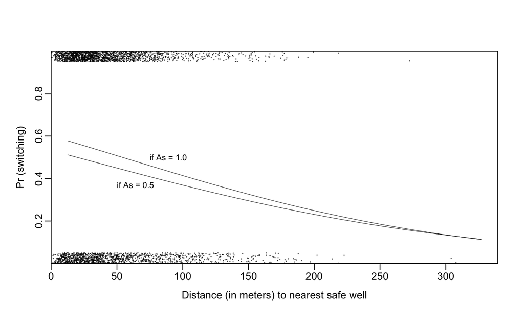

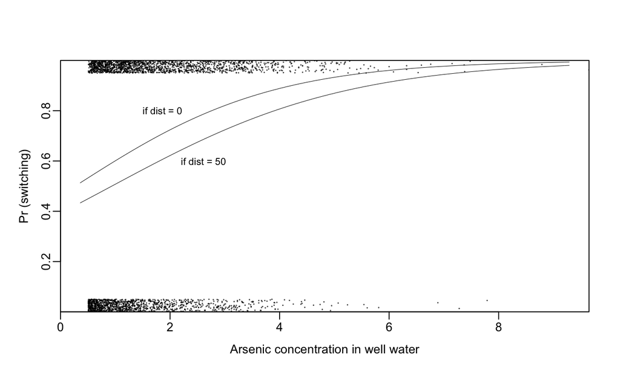

#### Adding social predictors

In order to improve interpretability of the results, we divide the education variable by 4 and we center the predictor.

***Extra* try to interpret the coefficients of the new model.

```r
## Adding social predictors

data$c.educ4 <- scale(data$educ/4, scale=FALSE)
fit.7 <- glm (switch ~ c.dist100 + c.arsenic + c.educ4 + c.dist100:c.arsenic, family=binomial(link="logit"), data=data)
summary(fit.7)
```

```
##
## Call:
## glm(formula = switch ~ c.dist100 + c.arsenic + c.educ4 + c.dist100:c.arsenic,
##     family = binomial(link = "logit"), data = data)
##
## Deviance Residuals:
##     Min       1Q   Median       3Q      Max
## -2.7149  -1.1886   0.7478   1.0689   1.7223
##
## Coefficients:
##                     Estimate Std. Error z value Pr(>|z|)
## (Intercept)          0.35271    0.04001   8.816  < 2e-16 ***
## c.dist100           -0.87462    0.10510  -8.322  < 2e-16 ***
## c.arsenic            0.47663    0.04228  11.273  < 2e-16 ***
## c.educ4              0.16922    0.03833   4.415 1.01e-05 ***
## c.dist100:c.arsenic -0.16291    0.10235  -1.592    0.111
## ---
## Signif. codes:  0 '***' 0.001 '**' 0.01 '*' 0.05 '.' 0.1 ' ' 1
##
## (Dispersion parameter for binomial family taken to be 1)
##
##     Null deviance: 4118.1  on 3019  degrees of freedom
## Residual deviance: 3907.9  on 3015  degrees of freedom
## AIC: 3917.9
##
## Number of Fisher Scoring iterations: 4
```

Moreover we add the interaction between the new variable and the predictors with the largest effects. The interpretation of the new interaction terms represent the effect of education on the effects of the other predictors. Positive changes in education reduce distance’s negative association and increasing education increases arsenic’s positive association.

```r
## Adding further interactions (centering education variable)

fit.8 <- glm (switch ~ c.dist100 + c.arsenic + c.educ4 + c.dist100:c.arsenic +
                c.dist100:c.educ4 + c.arsenic:c.educ4, family=binomial(link="logit"), data=data)
summary(fit.8)
```

```
##
## Call:
## glm(formula = switch ~ c.dist100 + c.arsenic + c.educ4 + c.dist100:c.arsenic +
##     c.dist100:c.educ4 + c.arsenic:c.educ4, family = binomial(link = "logit"),
##     data = data)
##
## Deviance Residuals:
##     Min       1Q   Median       3Q      Max
## -2.5706  -1.1964   0.7314   1.0724   1.8712
##
## Coefficients:
##                     Estimate Std. Error z value Pr(>|z|)
## (Intercept)          0.35630    0.04028   8.844  < 2e-16 ***
## c.dist100           -0.90286    0.10731  -8.414  < 2e-16 ***
## c.arsenic            0.49498    0.04305  11.497  < 2e-16 ***
## c.educ4              0.18498    0.03919   4.720 2.36e-06 ***
## c.dist100:c.arsenic -0.11768    0.10353  -1.137  0.25569
## c.dist100:c.educ4    0.32269    0.10662   3.026  0.00247 **
## c.arsenic:c.educ4    0.07223    0.04387   1.647  0.09965 .
## ---
## Signif. codes:  0 '***' 0.001 '**' 0.01 '*' 0.05 '.' 0.1 ' ' 1
##
## (Dispersion parameter for binomial family taken to be 1)
##
##     Null deviance: 4118.1  on 3019  degrees of freedom
## Residual deviance: 3891.7  on 3013  degrees of freedom
## AIC: 3905.7
##
## Number of Fisher Scoring iterations: 4
```

### Binned Residuals

Outcome variable in the logistic regression is discrete so the residuals. The plot of the residuals defined as
$$residual_i = y_i - E(y_i|X_i)=y_i-\text{logit}^-1(X_i\beta)$$
versus the fitted values is not useful.

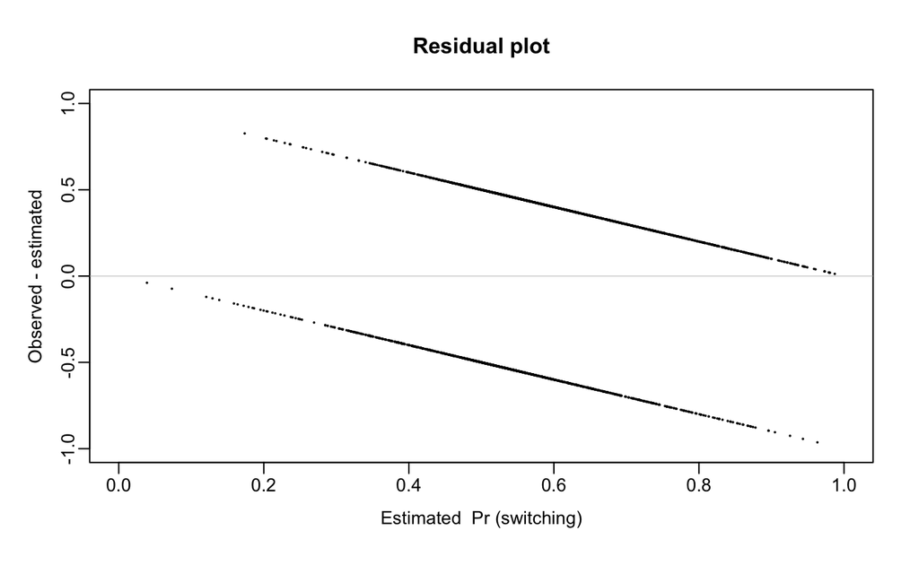

```r
## Residual Plot

pred.8 <- fit.8$fitted.values

plot(c(0,1), c(-1,1), xlab="Estimated  Pr (switching)", ylab="Observed - estimated", type="n", main="Residual plot", mgp=c(2,.5,0))
abline (0,0, col="gray", lwd=.5)
points (pred.8, data$switch-pred.8, pch=20, cex=.2)
```

A more readable plot can be made using the binned residuals defined as: *dividing the data into categories (bins) based on their fitted values, and then plotting the average residual versus the average fitted value for each bin* (Gelman, Hill 2007: 97). The number of bins have to be chosen such that each bin is computed on *enough* points such that the resulting plot is not too noisy (high number of bins) but can highlight patterns in the residuals (hided if the number of bins is too low).

Grey lines depict $\pm 2$ standard error bounds, so we expect that 95% of the binned residuals falls between these two lines. The standard error is defined as $\sqrt{p(1-p)/n}$, where $n$ is the number of data used to compute each average residual.

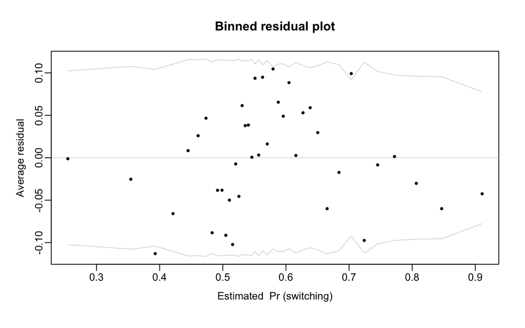

```r
### Binned residual Plot

 ## Defining binned residuals

binned.resids <- function (x, y, nclass=sqrt(length(x))){
  breaks.index <- floor(length(x)*(1:(nclass-1))/nclass)
  breaks <- c (-Inf, sort(x)[breaks.index], Inf)
  output <- NULL
  xbreaks <- NULL
  x.binned <- as.numeric (cut (x, breaks))
  for (i in 1:nclass){
    items <- (1:length(x))[x.binned==i]
    x.range <- range(x[items])
    xbar <- mean(x[items])
    ybar <- mean(y[items])
    n <- length(items)
    sdev <- sd(y[items])
    output <- rbind (output, c(xbar, ybar, n, x.range, 2*sdev/sqrt(n)))
  }
  colnames (output) <- c ("xbar", "ybar", "n", "x.lo", "x.hi", "2se")
  return (list (binned=output, xbreaks=xbreaks))
}

 ## Binned residuals vs. estimated probability of switching

br.8 <- binned.resids (pred.8, data$switch-pred.8, nclass=40)$binned
plot(range(br.8[,1]), range(br.8[,2],br.8[,6],-br.8[,6]), xlab="Estimated  Pr (switching)", ylab="Average residual", type="n", main="Binned residual plot", mgp=c(2,.5,0))
abline (0,0, col="gray", lwd=.5)
lines (br.8[,1], br.8[,6], col="gray", lwd=.5)
lines (br.8[,1], -br.8[,6], col="gray", lwd=.5)
points (br.8[,1], br.8[,2], pch=19, cex=.5)
```

A pattern can be idenitfied looking at he plot of the binned residuals with respect to the arsenic level. Indeed there are large negative binned residuals for some households with wells with small values of arsenic concentration. This points corresponds to people that are less likely to switch well with respect to what predicted by the model (almost $-20\%$). Moreover the distribution of the residuals shows a slight patter: the model seems to underestimate the probabilities of switching for medium arsenic level values while overestimates for high arsenic concentrations.

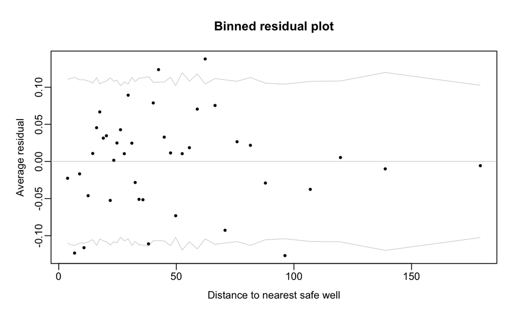

```r
## Plot of binned residuals vs. inputs of interest

  # distance

br.dist <- binned.resids(data$dist, data$switch-pred.8, nclass=40)$binned
plot(range(br.dist[,1]), range(br.dist[,2],br.dist[,6],-br.dist[,6]), xlab="Distance to nearest safe well", ylab="Average residual", type="n", main="Binned residual plot", mgp=c(2,.5,0))
abline (0,0, col="gray", lwd=.5)
lines (br.dist[,1], br.dist[,6], col="gray", lwd=.5)
lines (br.dist[,1], -br.dist[,6], col="gray", lwd=.5)
points (br.dist[,1], br.dist[,2], pch=19, cex=.5)
```

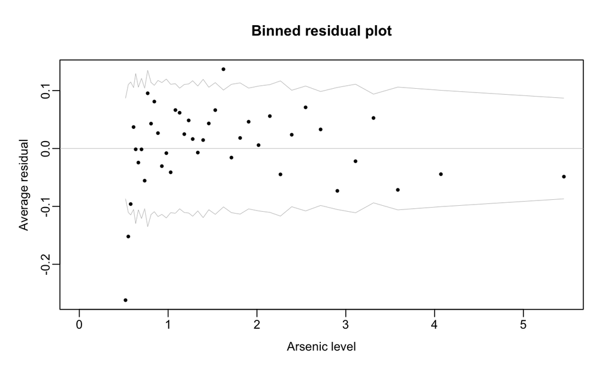

```r
  # arsenic

br.arsenic <- binned.resids(data$arsenic, data$switch-pred.8, nclass=40)$binned
plot(range(0,br.arsenic[,1]), range(br.arsenic[,2],br.arsenic[,6],-br.arsenic[,6]), xlab="Arsenic level", ylab="Average residual", type="n", main="Binned residual plot", mgp=c(2,.5,0))
abline (0,0, col="gray", lwd=.5)
lines (br.arsenic[,1], br.arsenic[,6], col="gray", lwd=.5)
lines (br.arsenic[,1], -br.arsenic[,6], col="gray", lwd=.5)
points (br.arsenic[,1], br.arsenic[,2], pch=19, cex=.5)
```

**Extra** propose a possible solution to improve the model and fit your model. Compare the new binned residual plots with the previous ones.

### Error rate

Error rate is defined as the proportion of cases for which the fitted probabilities are above 0.5 and the outocome value is 0 or the the fitted probabilities are below 0.5 and the outocome value is 1, that is when the prediction-guessing is wrong:
$$er <-mean((y=0 \& E(y|X)>.5)|(y=1 \& E(y|X)<.5))$$
It should be a value between 0 (perfect prediction-guessing) and 0.5 (random prediction-guessing) or the null model.

The null model is defined as a model with the only intercept. The estimated probability for the null model will be $p=\sum_i y_i/n$, that is the proportion of 1’s in the data. The error rate for the null model is $min(p, 1-p)$, and it corresponds to assign 1 (or 0) to all the fitted values.

```r
mean(data$switch)
```

```
## [1] 0.5751656
```

```r
error.rate <- mean((rep(1,length(data$switch))>0.5 & data$switch==0) |
                     ((rep(1,length(data$switch))<0.5 & data$switch==1)))
error.rate
```

```
## [1] 0.4248344
```

```r
error.rate <- mean((pred.8>0.5 & data$switch==0) | (pred.8<0.5 & data$switch==1))
error.rate
```

```
## [1] 0.3751656
```

Consider the error rate as the equivalent of the $R^2$ for the linear model, can be a useful measure of the model fit but don’t forget to evaluate your model looking at coefficients significance and at the diagnostic plot.

## Poisson regression

Suppose we collect some *counts*, $\boldsymbol{y}=(y_1,\ldots,y_n)$, say the daily average lengths of the phone calls for $n$ adults. For each adult, we register their age, their familiar status and their monthly earnings. We would like to predict the phone length in minutes. $x_1$ is the age predictor, $x_2$ the familiar status ($x_2=1$ if married/engaged, $x_2=0$ otherwise) and $x_3$ the monthly earning expressed in Euro/1000. The model we want to build is now:

$$y_i \sim \mathsf{Poiss}(\lambda),$$

with

$$g(\lambda)=g(E[y_i])=\beta_0+\beta_1x_{i1}+\beta_2x_{i2}+\beta_{3}x_{i3}+\epsilon_{i}$$
The usual choice in Poisson regression is to take $g(\cdot)=\log(\cdot)$.

Poisson models have a main drawback: the mean and the variance both equal $\lambda$. However, in may cases this is a major restriction, since data show a non negligible extent of **overdispersion**: data exhibit a greater variance than that assumed by the model.

If the model is true we expect the standardazed residuals to be approximately independend with mean 0 and standard deviation 1. In the standardazed residuals plot we should look for overdispersion.

```r
y <- c(4, 27, 2, 21, 8, 3, 3, 0, 4, 4, 5, 2, 2, 5, 7, 1, 5, 0, 15, 36)
age <- c(54 ,26,41,23, 41, 75, 28, 78, 44, 52, 50, 28, 42, 50, 31, 59, 33, 35, 26, 22)
family <- c(1,1,0,1,1,0,1,0,0,1,1,1,0,1,0,0,1,1,1,1)
earning <- c( 1.2, 5.3, 2.4, 6.3, 4.2, 1.5, 1.1, 0.9, 1.2, 1.1, 1.3, 1.5, 4.2, 1.3, 1.2, 1.3, 1.9, 2.7, 7.3, 5)
n <- length(y)
calls.glm <- glm(y ~ age+family+earning, family = poisson)
summary(calls.glm)
```

```
##
## Call:
## glm(formula = y ~ age + family + earning, family = poisson)
##
## Deviance Residuals:
##     Min       1Q   Median       3Q      Max
## -3.8605  -1.2867  -0.2356   0.9090   3.4575
##
## Coefficients:
##             Estimate Std. Error z value Pr(>|z|)
## (Intercept)  2.37911    0.58602   4.060 4.91e-05 ***
## age         -0.03729    0.01078  -3.458 0.000544 ***
## family       0.40259    0.27867   1.445 0.148546
## earning      0.19696    0.04662   4.225 2.39e-05 ***
## ---
## Signif. codes:  0 '***' 0.001 '**' 0.01 '*' 0.05 '.' 0.1 ' ' 1
##
## (Dispersion parameter for poisson family taken to be 1)
##
##     Null deviance: 179.973  on 19  degrees of freedom
## Residual deviance:  59.285  on 16  degrees of freedom
## AIC: 131.11
##
## Number of Fisher Scoring iterations: 5
```

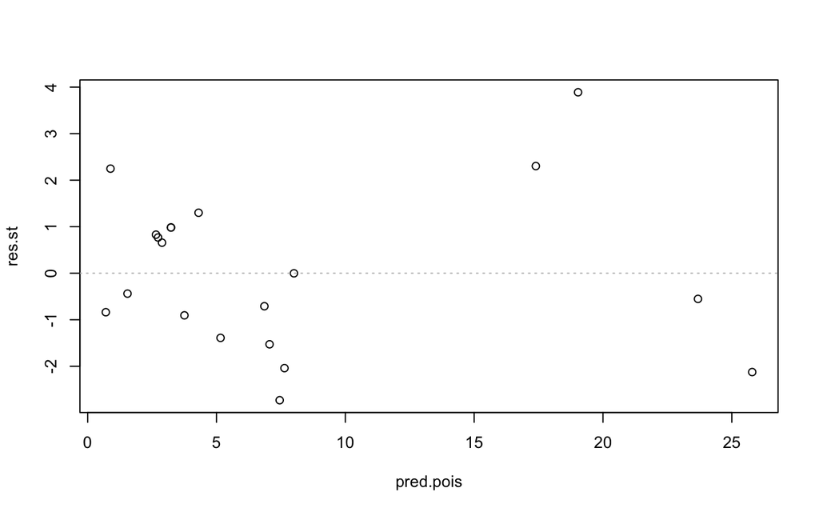

```r
pred.pois <- calls.glm$fitted.values
res.st <- (y-pred.pois)/sqrt(pred.pois)

plot(pred.pois, res.st)
abline(h=0,lty=3,col="gray75")
```

```r
est.overdispersion <- sum(res.st^2)/16
est.overdispersion
```

```
## [1] 3.358122
```

The idea is then to specify a *quasi Poisson* model, with:

$$\begin{cases}
E[y_i]=&\lambda\\
var(y_i)= &\phi E[y_i]
\end{cases}$$

where $\phi$ is the **overdispersion parameter**.

```r
calls.quasi.glm <- glm(y ~ age+family+earning, family = quasipoisson)
summary(calls.quasi.glm)
```

```
##
## Call:
## glm(formula = y ~ age + family + earning, family = quasipoisson)
##
## Deviance Residuals:
##     Min       1Q   Median       3Q      Max
## -3.8605  -1.2867  -0.2356   0.9090   3.4575
##
## Coefficients:
##             Estimate Std. Error t value Pr(>|t|)
## (Intercept)  2.37911    1.07389   2.215   0.0416 *
## age         -0.03729    0.01976  -1.887   0.0774 .
## family       0.40259    0.51066   0.788   0.4420
## earning      0.19696    0.08543   2.305   0.0349 *
## ---
## Signif. codes:  0 '***' 0.001 '**' 0.01 '*' 0.05 '.' 0.1 ' ' 1
##
## (Dispersion parameter for quasipoisson family taken to be 3.358123)
##
##     Null deviance: 179.973  on 19  degrees of freedom
## Residual deviance:  59.285  on 16  degrees of freedom
## AIC: NA
##
## Number of Fisher Scoring iterations: 5
```

```r
par(mfrow=c(1,2))
```